# Syntax Tugas Kelompok

# Analisis sisaan

### Eksplorasi

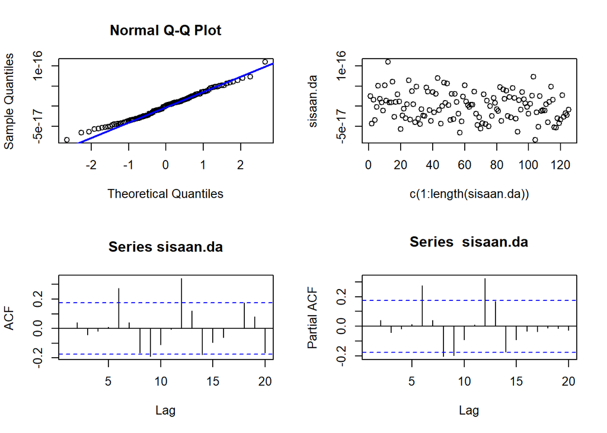

```r
#Eksplorasi
sisaan.da <- model2$residuals
par(mfrow=c(2,2))
qqnorm(sisaan.da)
qqline(sisaan.da, col = "blue", lwd = 2)
plot(c(1:length(sisaan.da)),sisaan.da)
acf(sisaan.da)
pacf(sisaan.da)
```

```r
par(mfrow = c(1,1))
```

### Uji Formal

```r
#1) Sisaan Menyebar Normal
ad.test(sisaan.da)
```

```
##
##  Anderson-Darling normality test
##
## data:  sisaan.da
## A = 0.31859, p-value = 0.5316
```

$H_0$ : Sisaan menyebar normal $H_1$ : Sisaan tidak menyebar normal

Berdasarkan uji Anderson-Darling tersebut, didapat *p-value* sebesar 0.5316 yang lebih dari taraf nyata 5% sehingga tak tolak $H_0$ dan menandakan bahwa sisaan menyebar normal. Hal ini sesuai dengan hasil eksplorasi menggunakan plot kuantil-kuantil normal.

```r
#2) Sisaan saling bebas/tidak ada autokorelasi
Box.test(sisaan.da, type = "Ljung")
```

```
##
##  Box-Ljung test
##
## data:  sisaan.da
## X-squared = 0.00081513, df = 1, p-value = 0.9772
```

$H_0$ : Sisaan saling bebas $H_1$ : Sisaan tidak tidak saling bebas

Berdasarkan uji Ljung-Box tersebut, didapat *p-value* sebesar 0.9772 yang lebih besar dari taraf nyata 5% sehingga tak tolak $H_0$ dan menandakan bahwa sisaan saling bebas. Artinya tidak ada autokorelasi.

```r
#3) Sisaan homogen
Box.test((sisaan.da)^2, type = "Ljung")
```

```
##
##  Box-Ljung test
##
## data:  (sisaan.da)^2
## X-squared = 1.274, df = 1, p-value = 0.259
```

$H_0$ : Ragam sisaan homogen $H_1$ : Ragam sisaan tidak homogen

Berdasarkan uji Ljung-Box tersebut. didapat *p-value* sebesar 0.259 yang lebih besar dari taraf nyata 5% sehingga tak tolak $H_0$ dan menandakan bahwa ragam sisaan homogen.

```r
#4) Nilai tengah sisaan sama dengan nol
t.test(sisaan.da, mu = 0, conf.level = 0.95)  #tak tolak h0 > nilai tengah sisaan sama dengan 0
```

```
##
##  One Sample t-test
##
## data:  sisaan.da
## t = -0.06344, df = 124, p-value = 0.9495
## alternative hypothesis: true mean is not equal to 0
## 95 percent confidence interval:
##  -6.319087e-18  5.926587e-18
## sample estimates:
##     mean of x
## -1.962501e-19
```

$H_0$ : nilai tengah sisaan sama dengan 0 $H_1$ : nilai tengah sisaan tidak sama dengan 0

Berdasarkan uji-ttersebut, didapat *p-value* sebesar 0.9495 yang lebih besar dari taraf nyata 5% sehingga tak tolak $H_0$ dan menandakan bahwa nilai tengah sisaan sama dengan 0.

# Overfitting

```r
model6=Arima(train.ts, order=c(2,0,1),method="ML")
summary(model6) #AIC=-9111.2
```

```
## Series: train.ts
## ARIMA(2,0,1) with non-zero mean
##
## Coefficients:
```

```
##          ar1      ar2     ma1  mean
##       0.8881  -0.3024  0.0259     0
## s.e.  0.1491   0.1081  0.1970   NaN
##
## sigma^2 = 1.226e-33:  log likelihood = 4560.59
## AIC=-9111.19   AICc=-9110.68   BIC=-9097.05
##
## Training set error measures:
##                         ME         RMSE          MAE       MPE     MAPE
## Training set -2.244343e-19 3.444576e-17 2.823245e-17 -3.351875 14.85584
##                   MASE      ACF1
## Training set 0.8900849 -0.001233
```

```r
lmtest::coeftest(model6) #Terdapat parameter tidak signifikan
```

```
##
## z test of coefficients:
##
##              Estimate  Std. Error z value Pr(>|z|)
## ar1        8.8808e-01  1.4910e-01  5.9563 2.58e-09 ***
## ar2       -3.0243e-01  1.0811e-01 -2.7975 0.005149 **
## ma1        2.5934e-02  1.9698e-01  0.1317 0.895254
## intercept  2.0775e-16         NaN     NaN      NaN
## ---
## Signif. codes:  0 '***' 0.001 '**' 0.01 '*' 0.05 '.' 0.1 ' ' 1
```

Berdasarkan hasil overfitting, model terbaik tetap model ARIMA(2,0,0)

# Peramalan

```r
#---FORECAST---#
ramalan <- forecast::forecast(model2, h = 31)
ramalan
```

```
##     Point Forecast        Lo 80        Hi 80        Lo 95        Hi 95
## 126   1.874387e-16 1.427524e-16 2.321250e-16 1.190969e-16 2.557805e-16
## 127   2.008151e-16 1.403577e-16 2.612724e-16 1.083535e-16 2.932766e-16
## 128   2.078725e-16 1.432311e-16 2.725139e-16 1.090120e-16 3.067330e-16
## 129   2.100441e-16 1.449240e-16 2.751642e-16 1.104515e-16 3.096367e-16
## 130   2.097758e-16 1.446556e-16 2.748959e-16 1.101831e-16 3.093685e-16
## 131   2.088397e-16 1.436675e-16 2.740119e-16 1.091674e-16 3.085120e-16
## 132   2.080721e-16 1.428579e-16 2.732863e-16 1.083356e-16 3.078086e-16
## 133   2.076707e-16 1.424435e-16 2.728979e-16 1.079143e-16 3.074272e-16
## 134   2.075494e-16 1.423207e-16 2.727781e-16 1.077907e-16 3.073081e-16
## 135   2.075666e-16 1.423379e-16 2.727953e-16 1.078079e-16 3.073253e-16
## 136   2.076210e-16 1.423921e-16 2.728499e-16 1.078620e-16 3.073800e-16
## 137   2.076650e-16 1.424360e-16 2.728940e-16 1.079058e-16 3.074242e-16
## 138   2.076878e-16 1.424588e-16 2.729169e-16 1.079286e-16 3.074471e-16
## 139   2.076946e-16 1.424655e-16 2.729237e-16 1.079353e-16 3.074539e-16
```

[output cut: 17 more lines]

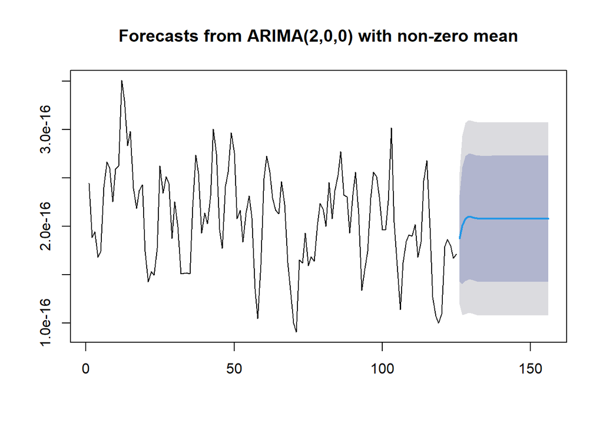

```r
data.ramalan <- ramalan$mean
plot(ramalan)
```

Berdasarkan hasil plot ramalan di atas, dapat dilihat bahwa ramalan ARIMA(2,0,0) cenderung stabil hingga akhir periode. Selanjutnya, dapat dicari nilai akurasi antara hasil ramalan dengan data uji sebagai berikut.

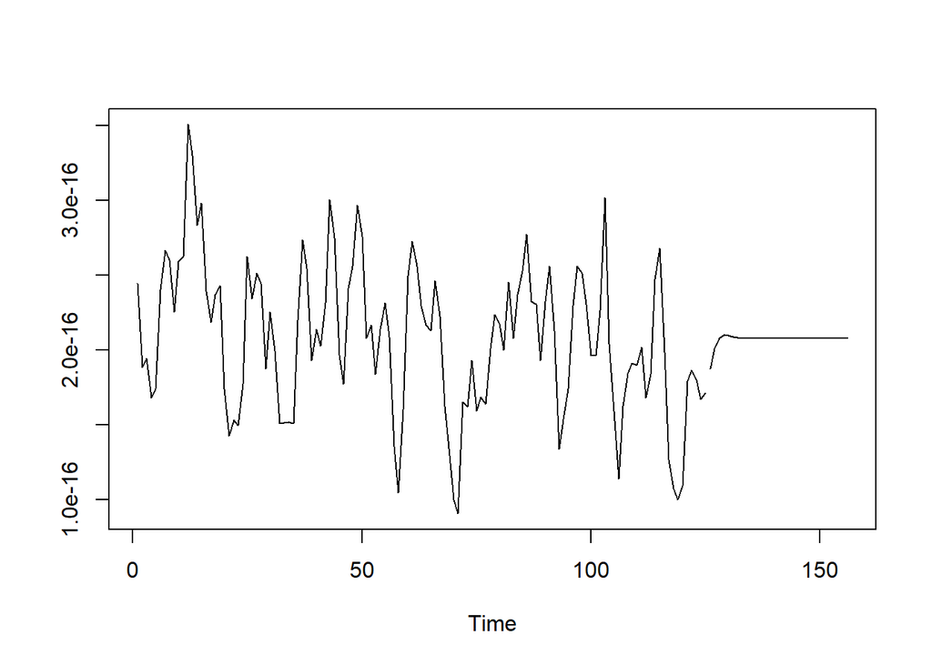

```r
pt_1 <- train.ts[115] #nilai akhir data latih
hasil <- data.ramalan
ts.plot(train.ts,hasil)
```

# AKURASI

```r
perbandingan <- matrix(data=c(head(test.ts, n=31), hasil[-1]),
                     nrow = 31, ncol = 2)
colnames(perbandingan)<-c("Aktual","Hasil Forecast")
perbandingan
```

```
##             Aktual Hasil Forecast
##  [1,] 2.191247e-16   2.008151e-16
##  [2,] 2.656327e-16   2.078725e-16
##  [3,] 2.504297e-16   2.100441e-16
##  [4,] 2.218699e-16   2.097758e-16
##  [5,] 2.182178e-16   2.088397e-16
##  [6,] 1.798865e-16   2.080721e-16
##  [7,] 2.472970e-16   2.076707e-16
##  [8,] 2.514835e-16   2.075494e-16
##  [9,] 2.401523e-16   2.075666e-16
## [10,] 2.312952e-16   2.076210e-16
## [11,] 2.164164e-16   2.076650e-16
## [12,] 1.791553e-16   2.076878e-16
## [13,] 2.303333e-16   2.076946e-16
## [14,] 2.411590e-16   2.076935e-16
```

[output cut: 17 more lines]

```r
accuracy(ts(hasil[-1]), head(test.ts, n=31))
```

```
##                    ME         RMSE          MAE      MPE     MAPE      ACF1
## Test set 1.661471e-17 2.959382e-17 2.583442e-17 6.210906 11.31178 0.1950628
##          Theil's U
## Test set 0.8660958
```

### Transformasi Balik

```r
perbandingan <- matrix(data=c(head((test.ts)^(-1/11), n=31), (hasil[-1])^(-1/11)),
                     nrow = 31, ncol = 2)
colnames(perbandingan)<-c("Aktual","Hasil Forecast")
perbandingan
```

```
##       Aktual Hasil Forecast
##  [1,]  26.52       26.73120
##  [2,]  26.06       26.64740
##  [3,]  26.20       26.62223
##  [4,]  26.49       26.62533
##  [5,]  26.53       26.63616
##  [6,]  27.00       26.64507
##  [7,]  26.23       26.64975
##  [8,]  26.19       26.65117
##  [9,]  26.30       26.65097
## [10,]  26.39       26.65033
## [11,]  26.55       26.64982
## [12,]  27.01       26.64955
## [13,]  26.40       26.64947
## [14,]  26.29       26.64949
```

[output cut: 17 more lines]

```r
accuracy(ts((hasil[-1])^(-1/11)), head((test.ts)^(-1/11), ))
```

```
##                  ME      RMSE       MAE        MPE     MAPE      ACF1 Theil's U
## Test set -0.1845657 0.3472467 0.3028745 -0.7097427 1.147924 0.2714948  1.126363
```